# COMP1014 / MATH7016 Assignment Autumn 2025

## Question 3

Test whether participants who use melatonin supplements have significantly longer average sleep durations than those who don’t.

## Question 4

Test whether average sleep duration vary significantly across different genders.

### Q5. Test if screen time before bed can be used to predict average sleep duration among office workers.

```r
# Load csv file
SleepCogStudy <- read.csv("Resources/Sleep_Cognition_Study_f1PhaXA.csv")

#H0: Screen time before bed has no effect on average sleep duration
#HA: Screen time before bed significantly predicts average sleep duration

#H0: m1 = 0
#hA: m1 =/= 0

#Filter data to office workers
office_data <- subset(SleepCogStudy, OccupationType == "Office Worker")

# Fit linear regression model
fit <- lm(AverageSleepDuration ~ ScreenTimeBeforeBed, data = office_data)
summary(fit)
```

```
##
## Call:
## lm(formula = AverageSleepDuration ~ ScreenTimeBeforeBed, data = office_data)
##
## Residuals:
##      Min       1Q   Median       3Q      Max
## -1.58921 -0.59066 -0.07945  0.72796  2.20174
##
## Coefficients:
##                      Estimate Std. Error t value Pr(>|t|)
## (Intercept)          8.951029   0.409653  21.850  < 2e-16 ***
## ScreenTimeBeforeBed -0.023919   0.005378  -4.448 3.41e-05 ***
## ---
## Signif. codes:  0 '***' 0.001 '**' 0.01 '*' 0.05 '.' 0.1 ' ' 1
##
## Residual standard error: 0.8172 on 66 degrees of freedom
## Multiple R-squared:  0.2306, Adjusted R-squared:  0.2189
## F-statistic: 19.78 on 1 and 66 DF,  p-value: 3.411e-05
```

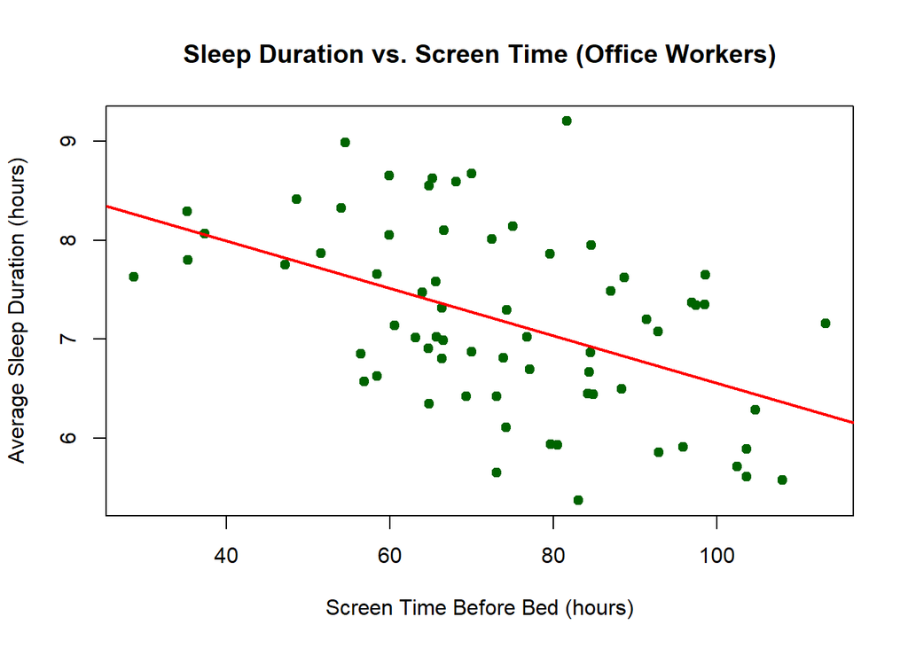

```r
#plot Sleep Duration vs. Screen Time
plot(office_data$ScreenTimeBeforeBed, office_data$AverageSleepDuration,
     main = "Sleep Duration vs. Screen Time (Office Workers)",
     xlab = "Screen Time Before Bed (hours)",
     ylab = "Average Sleep Duration (hours)",
     pch = 19, col = "darkgreen")
abline(fit, col = "red", lwd = 2)
```

## Question 6

Which of your results surprised you and why? What would you test if you had more time and interest?

Only create a question and explain the solution method in words.